# Hourly Wage analysis using MORG-CPS 2018

Author

Fernando Rios-Avila

## Setup

For the following analysis, all the data process is done in the file `example.do`.

This do-file loads the data and creates auxiliary variables that mimic the interval censoring of the data (in this case wages).

Using the brackets data, it estimates the heteroskedastic interval regression model, and then uses the `intreg_mi` command to obtain the imputations for the data. We assume 3 cases, where data is categorized in 5, 7, and 10 groups.

The imputed data is then used to estimate conditional and unconditional quantile regressions, using the fully observed data, and the imputed data.

The results are then saved in a matrix, and then used to create the figures.

```stata
ssc install frause
run example.do
```

## Model Specification

For Imputation we assume wages are a function of the following variables: month in sample, age, age squared, gender, highest degree obtained, if worked less than 35hrs a week, class of worker, if usually receives Overtime and Tips, Is a union member, presence and number of own children in the household, relation to family members, and marital status.

For modeling, we only consider age and age squared, gender, highest degree obtained, if is a union member or not, marital status and if there is a child present.

Only a selected set of variables are used for the plots.

## Ploting Conditional and Unconditional Quantile Regressions

**5 groups**

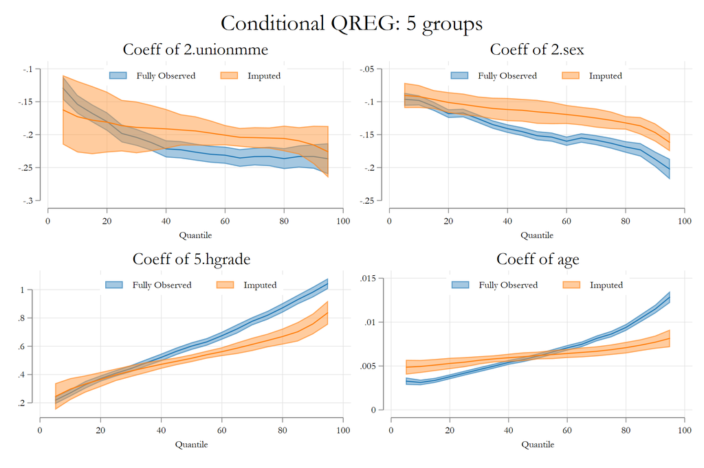

Conditional Quantile Regression

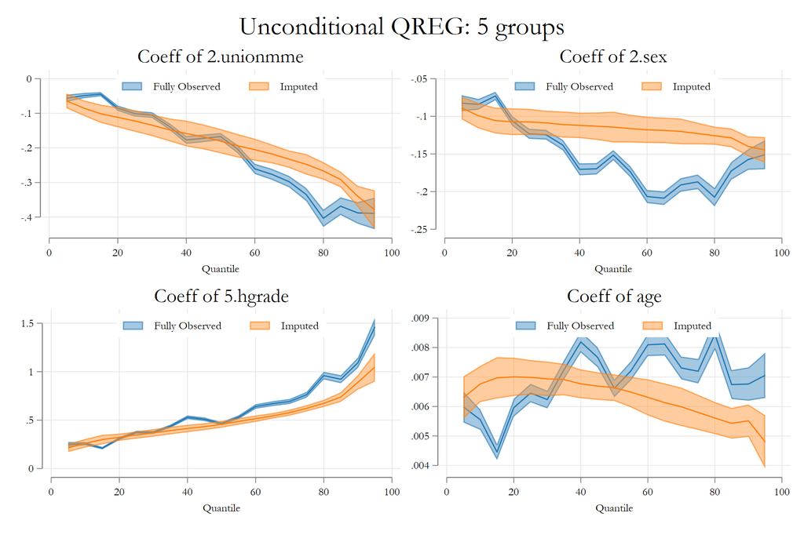

Unconditional Quantile Regression

**7 groups**

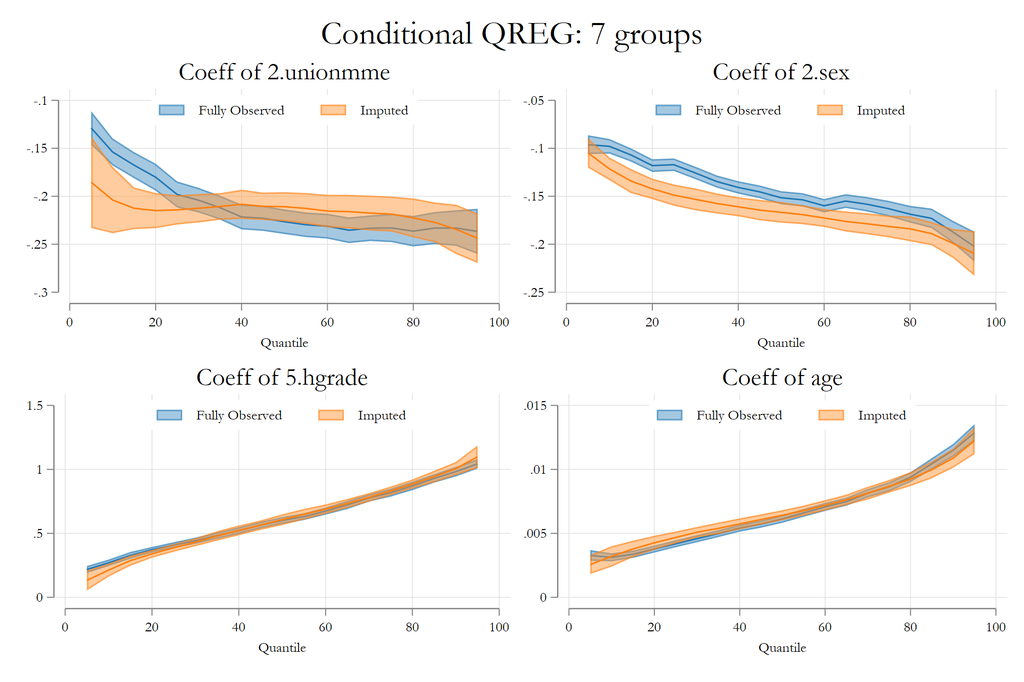

Conditional Quantile Regression

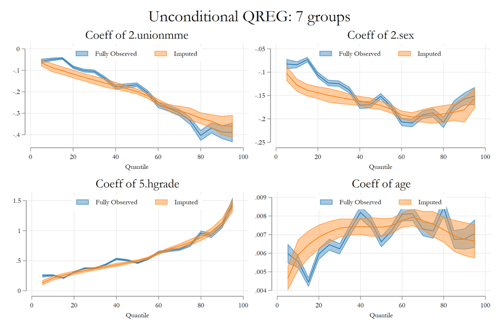

Unconditional Quantile Regression

**10 groups**

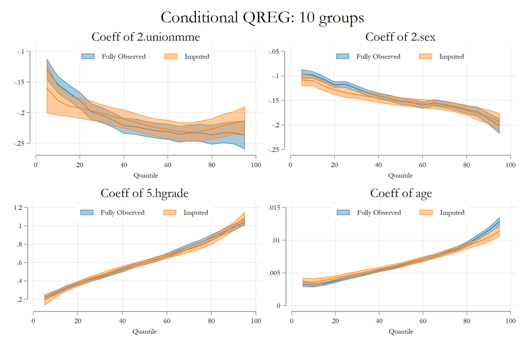

Conditional Quantile Regression

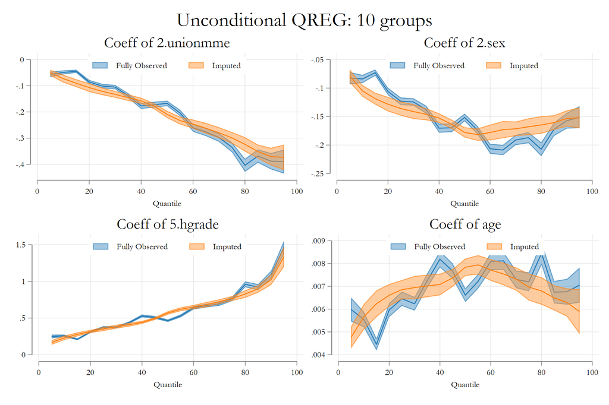

Unconditional Quantile Regression